# Short report on campaign 03

30/01/2024 - 29/02/2024

*Last update: 10/09/2025*

## Introduction

The collection of field data is an important element of the HydroCORE project. It allows to make an assessment of the state of the Paute river system and to identify patterns in both space and time. It is expected that these conditions change along the path of the Paute river due to a variety of human and natural influences. For instance, the city of Cuenca is situated in the upstream part of the basin, while two reservoirs are present in the downstream part prior to entering the Amazon region.

To characterise the Paute river system, the HydroCORE project foresees a total of eight sampling campaigns over a period of two years. Abiotic conditions are recorded every three months and supplemented with the collection of macroinvertebrates every six months. At the spatial level, the project aims to include 20 reservoir sites and 30 river sites (totaling 50 sampling sites). These also include sites that are part of a reference system in which no artificial reservoirs are present, being the Jubones river system.

The third sampling campaign was performed from 30 January 2024 until 29 February 2024. During this period, a total of 52 sampling sites were visited. The results of the abiotic analyses performed both *on-site* (observations of the field conditions, probe readings) as *off-site* (nutrient analyses) are reported here in a concise manner. More results (e.g., macroinvertebrate communities) will be added later.

## Map of the sampling sites

A total of 52 sampling sites were visited and distributed as follows: (1) 20 river sites, (2) 21 reservoir sites, and (3) 11 reference system sites. The majority of the river sites (*N* = 14) is located upstream of the two reservoirs, while the majority of the reservoir sites (*N* = 16) is located in the largest reservoir (called Mazar). Relatively few reservoir sites (*N* = 5) were visited in the smaller reservoir (called Amaluza) due to accessibility reasons. There are hardly roads leading to the reservoir due to the steep mountains and a large fraction of the water surface is overcrowded by water hyacinth (*E. crassipes*). The map shows where the sampling sites are situated:

[interactive chart not shown]

Figure 1: Map of the sampling locations.

## Physicochemical conditions

At every sampling site, a series of water quality parameters were recorded. In addition, water samples were collected in plastic bottles for nutrient analysis in the lab at UCuenca. Within this section, the results of these analyses are presented in a concise manner and further explored through principal component analysis and hierarchical clustering. Through this exploration, similarities and dissimilarities between sampling sites can be observed.

### Statistical summary

A first step in the data exploration is looking at the characteristic statistics of the considered variables. This provides an idea of the range of the obtained values and indicates if (and where) data is missing. For this overview, a distinction is made between the parameters measured *on-site* and *off-site*.

An overall summary of the parameters that were measured *on-site* is given in Table 1, showing an altitude range between 915 m and 3105 m above sea level. Dissolved oxygen levels ranged from 2.30 mg/L up to 14.55 mg/L, averaging at 11.35 mg/L (SD = 1.91 mg/L). Also turbidity and chlorophyll *a* displayed a rather wide range (1.00 NTU up to 314 NTU and 4.77 µg/L up to 789.40 µg/L, respectively), while salinity showed to be more constant.

Table 1: Summary of the on- and off-site variables

|  | Min | Q1 | Median | Q3 | Max | Mean | SD | #NA |
| --- | --- | --- | --- | --- | --- | --- | --- | --- |
| Altitude [m a.s.l.] | 915.00 | 1984.00 | 2129.00 | 2206.00 | 3105.00 | 2074.10 | 412.70 | 0 |
| Distance | 0.35 | 36.24 | 46.67 | 64.07 | 143.08 | 54.53 | 33.05 | 0 |
| Temperature [oC] | 10.52 | 15.20 | 17.88 | 19.34 | 23.25 | 17.27 | 3.05 | 0 |
| pH [-] | 6.52 | 7.14 | 7.66 | 8.01 | 8.93 | 7.61 | 0.65 | 0 |
| Conductivity [mS/cm] | 0.03 | 0.10 | 0.17 | 0.18 | 0.62 | 0.15 | 0.08 | 0 |
| Salinity [ppt] | 0.00 | 0.00 | 0.10 | 0.10 | 0.30 | 0.07 | 0.06 | 0 |
| Oxygen saturation [%] | 25.40 | 114.65 | 122.55 | 133.65 | 155.30 | 121.48 | 20.38 | 0 |
| Oxygen [mg/L] | 2.30 | 10.64 | 11.47 | 12.43 | 14.55 | 11.35 | 1.91 | 0 |
| Total dissolved solids [g/L] | 0.02 | 0.06 | 0.11 | 0.12 | 0.40 | 0.10 | 0.05 | 0 |
| Oxidation reduction potential [ORPmV] | 92.00 | 272.00 | 304.00 | 330.00 | 400.00 | 302.58 | 52.53 | 0 |
| Turbidity [NTU] | 1.00 | 3.40 | 7.90 | 18.50 | 314.00 | 23.04 | 50.73 | 0 |
| Chlorophyll a [ug/L] | 4.77 | 25.11 | 46.50 | 87.22 | 789.40 | 102.08 | 169.72 | 0 |
| Average velocity [m/s] | 0.00 | 0.00 | 0.17 | 0.54 | 1.07 | 0.30 | 0.32 | 1 |
| TOC [mg/L] | 1.47 | 3.19 | 3.81 | 5.97 | 18.15 | 5.13 | 3.42 | 0 |
| TIC [mg/L] | 2.85 | 6.41 | 8.34 | 10.64 | 32.00 | 8.96 | 4.22 | 0 |
| Total carbon [mg/L] | 5.05 | 10.90 | 13.11 | 16.20 | 37.63 | 14.09 | 5.82 | 0 |
| Nitrate-N [mg/L] | 0.50 | 0.50 | 0.53 | 0.92 | 1.27 | 0.71 | 0.26 | 0 |
| Nitrite-N [mg/L] | 0.00 | 0.00 | 0.01 | 0.04 | 0.18 | 0.03 | 0.03 | 0 |
| Ammonium-N [mg/L] | 0.00 | 0.01 | 0.04 | 0.09 | 1.07 | 0.10 | 0.18 | 0 |
| Orthophosphate-P [mg/L] | 0.00 | 0.00 | 0.01 | 0.03 | 0.18 | 0.04 | 0.05 | 0 |
| Total-N [mg/L] | 0.50 | 0.50 | 1.11 | 1.36 | 2.53 | 1.11 | 0.56 | 0 |
| Total-P [mg/L] | 0.00 | 0.04 | 0.06 | 0.16 | 1.16 | 0.13 | 0.19 | 0 |

### Correlation analysis

The different variables of the previous sections were used as a basis for a correlation analysis (see Figure 2). From this analysis, it is clear that some variables are more correlated than others (as is expected). Salinity, conductivity, and total dissolved solids show a higher-than-average correlation as they more or less reflect the amount of dissolved chemicals in the water column. Also the different nutrients display a higher correlation, especially regarding ammonia-nitrogen, nitrite-nitrogen, and total nitrogen. Nitrate-nitrogen showed a lower correlation with the other nitrogen compounds, which might be related to the relatively low variability in the observed value due to the quantification limit of 0.5 mgN/L used during the analysis (see Table 1).

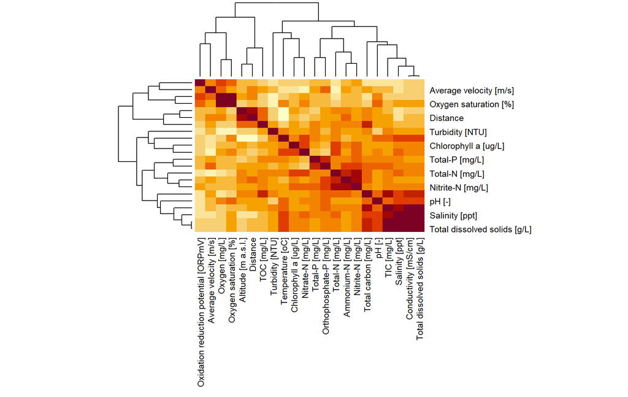

Figure 2: Correlation analysis of the various variables.

### Principal component analysis

The PCA shows that there is no clear clustering of all sampling sites (see Figure 3), which is partially in line with the observed nutrient levels (see Table 1). Sites that showed discrepancy from the majority of the sites included the Cuenca (code ‘CU’) and Paute river (code ‘PA’), displaying relatively higher nutrient levels. Also, location CU05 shows a clear difference, mostly due to the relatively high conductivity that was observed.

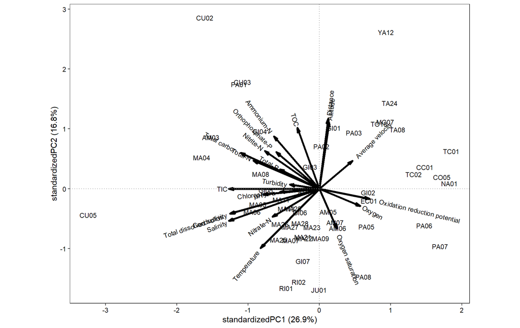

Figure 3: PCA of the physicochemical data.

### Supervised clustering

In addition to the unsupervised analysis provided by PCA, a supervised cluster analysis can be performed to identify (dis)similarities between sampling sites. These (dis)similarities can be calculated through distances, with the Euclidean distance being the most frequently used. Subsequently, clusters are created based on these distances by using a specific linkage technique. Here, Euclidean distances and a complete linkage is being used.

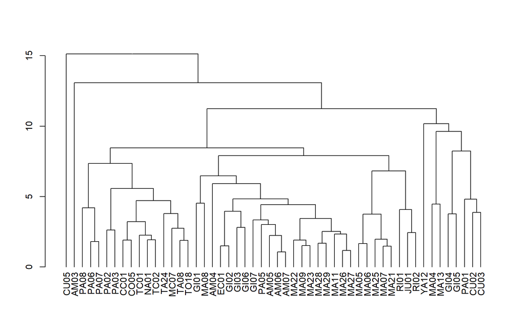

Figure 4: Hierarchical clustering of the sample sites.

## Greenhouse gases

Aside from the abovementioned physicochemical conditions, additional samples were collected to determine (1) the presence of greenhouse gases in a dissolved state within the water column and (2) the emission of greenhouse gases to the atmosphere. Samples were collected in 12 mL glass vials that were pre-rinsed with Helium and subsequently analysed at ETH Zürich. Within this section, the results of these analyses are presented in a concise manner and further explored through principal component analysis and hierarchical clustering. Through this exploration, similarities and dissimilarities between sampling sites can be observed.

### Statistical summary

Similar to the section on the physicochemical conditions, we start with a look at the characteristic statistics of the considered variables. For this overview, a distinction is made between dissolved greenhouse gases and the calculated emissions.

An overall summary is given in Table 2, showing that the level of carbon dioxide in the water column ranged from 21.94 µM up to 918.20 µM, averaging at 66.27 µM (SD = 124.15 µM). Methane levels ranged from 0.07 µM up to 19.78 µM and averaged at 0.81 µM (SD = 2.81 µM). Nitrous oxide levels showed to be relatively uniform and clearly lower than the carbon-based gases.

In addition, Table 2 also contains a summary of the emitted greenhouse gases. Especially interesting here is the negative flux for carbon dioxide (at -489 mg/m²/d), suggesting a local net uptake of carbon dioxide. Also the maximum emission rate for both carbon dioxide (5617 mg/m²/d) and methane (1069 mg/m²/d) are worth mentioning, though they might be influenced by ebullition taking place right under the collecting chamber.

Table 2: Summary of the dissolved and emitted greenhouse gases.

|  | Min | Q1 | Median | Q3 | Max | Mean | SD | #NA |
| --- | --- | --- | --- | --- | --- | --- | --- | --- |
| Nitrous oxide [uM] | 0.02 | 0.02 | 0.02 | 0.03 | 0.07 | 0.03 | 0.01 | 0 |
| Methane [uM] | 0.07 | 0.10 | 0.22 | 0.58 | 19.78 | 0.81 | 2.81 | 0 |
| Carbon dioxide [uM] | 21.94 | 31.85 | 39.39 | 57.21 | 918.20 | 66.27 | 124.15 | 0 |
| Nitrous oxide [mg/m²/d] | -0.01 | 0.03 | 0.17 | 0.34 | 2.31 | 0.26 | 0.40 | 14 |
| Carbon dioxide [mg/m²/d] | -489.38 | 115.08 | 338.74 | 1378.17 | 5617.33 | 877.00 | 1297.37 | 10 |
| Methane [mg/m²/d] | 0.07 | 1.17 | 2.94 | 10.62 | 1069.39 | 43.43 | 166.73 | 8 |

### Correlation analysis

The different variables of the previous sections were used as a basis for a correlation analysis (see Figure 5). As is expected, strong correlations are observed between the dissolved and emitted quantities of nitrous oxide, though the relationships between the carbon-based gases are clearly different from previous campaigns. This time, a strong correlation is observed for dissolved methane and carbon dioxide, followed by a correlation with the emitted carbon dioxide.

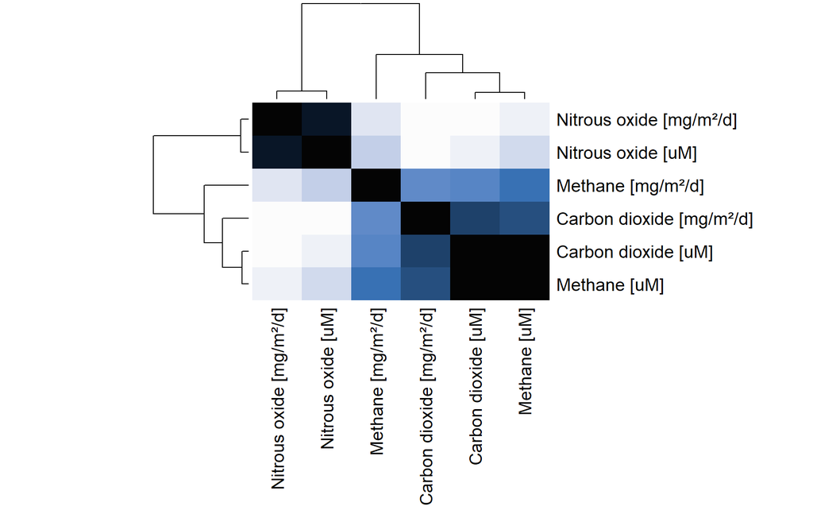

Figure 5: Correlation analysis of the greenhouse gases.

### Principal component analysis

In alignment with the physicochemical conditions, dimensionality reduction can be applied. Principal component analysis (PCA) shows that the first component is mostly determined by the carbon-based greenhouse gases and that the second principal component is additionally determined by nitrous oxide.

The PCA shows that the majority of sampling sites cluster together (see Figure 6). Sites that showed discrepancy from the majority of the sites included the Amaluza (code ‘AM’) and Mazar (code ‘MA’) reservoir, with a special mentioning for MA07. These sites are characterised by a relatively high emission of the considered greenhouse gases and might mask any further clustering of the other sites.

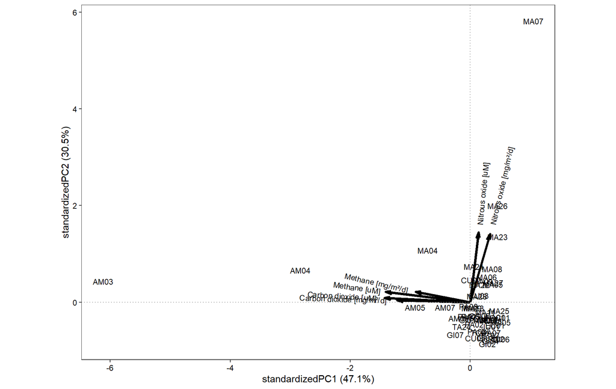

Figure 6: PCA of the greenhouse gas data.

### Supervised clustering

In addition to the unsupervised analysis provided by PCA, the supervised cluster analysis displays the closeness of the different sampling sites and shows that spatially close sites do not always cluster together (see Figure 7). Some closely situated sites do cluster together (e.g., GI05/06, MA21/23, PA02/03), while others end up further away in the tree (e.g., MA04/05, GI04/05, MA25/26). Some overlap with the PCA result can also be seen, including the discrepancy of AM03, MA07, and AM04 with the majority of sampling sites.

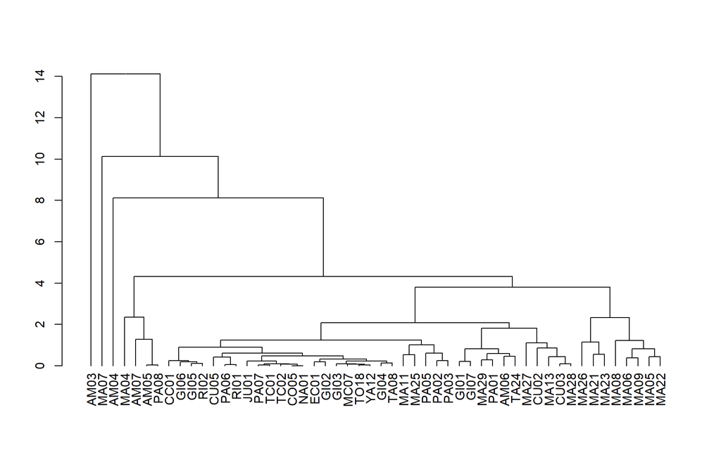

Figure 7: Hierarchical clustering of the sample sites.

## Summary

A total of 52 sampling sites were selected and assessed for a variety of water quality parameters and a set of greenhouse gases. Surprisingly, nutrient levels were higher than observed during the first sampling campaign (July-August 2023) and lower than observed during the second campaign (October-November 2023), though nitrate levels were often too low to be quantified. Several sampling sites seem to show different conditions, most of them located near/downstream of urbanisation. For example, the Cuenca (CU02/03) and Paute (PA01/02/03) sites are situated downstream of Cuenca, while the Giron sites are situated in and downstream of the town of Giron. This time, exceptionally high greenhouse gas concentrations and emissions were found in various reservoirs sites, both in Amaluza and Mazar.

## Acknowledgement

We would like to thank C.X. Lopez Solis and K.P. Ramirez Pozo for their help in collecting the samples in the field as well as their subsequent processing in the lab. We also thank D.G. Zuñiga Villegas for providing us with the necessary transport and M. Barthel for the analyses of the greenhouse gas samples.

## Reference

Van Echelpoel, W. (2025). *Short report on campaign 03*. HydroCORE project. Online: https://wvechelp.github.io/HydroCORE/Reports/ShortReportCampaign03.html

Read more on the [HydroCORE webpage](https://wvechelp.github.io/HydroCORE/).